# The Simpsons Series Study

The Simpsons is a TV show that has over thirty different seasons, dating back to 1989, when it first started. This resulted in the Simpsons taking away the title of longest running American prime-time scripted television series from Gunsmoke of 20 season. Matt Groening and James L. Brooks have both served as two of the main executive producers of the show. There is currently 32 complete seasons of the Simpsons and confirmed to run untill the end of Season 34. With over 650 episodes there has to be a certain algorythm that makes s great Simpsons episode. For the study done in this file, I will be focusing on all seasons up to season 28, as that is the newest season avaible in the data set. The source of the data set can be found [here](https://drive.google.com/drive/folders/1s8tbsZGisZb0KG1rJEAs9FhB5F5Z4s-e?usp=share_link). These are some of the ways that I am planing to study the date. Is there a correlation between the length of an episode title and the number of views? What year produces the episodes with the largest viewer count? IMDB rating vs. viewer count What seasons had the most views. Were the earlier episodes more popular episodes in a given season?

```python
cd /content/drive/MyDrive/Year 1/Spring Semester/DTSC - 220-1 Intro to Data Science
```

```
/content/drive/MyDrive/Year 1/Spring Semester/DTSC - 220-1 Intro to Data Science
```

```python
cd Main_Project/
```

```
/content/drive/MyDrive/Year 1/Spring Semester/DTSC - 220-1 Intro to Data Science/Main_Project
```

```python
import numpy as np
import pandas as pd
import matplotlib.pyplot as plt
```

## Importing Data

```python
main = pd.read_csv('simpsons_episodes.csv')
```

```python
main.head()
```

|  | id | image_url | imdb_rating | imdb_votes | number_in_season | number_in_series | original_air_date | original_air_year | production_code | season | title | us_viewers_in_millions | video_url | views |
| --- | --- | --- | --- | --- | --- | --- | --- | --- | --- | --- | --- | --- | --- | --- |
| 0 | 10 | http://static-media.fxx.com/img/FX_Networks_-_... | 7.4 | 1511.0 | 10 | 10 | 1990-03-25 | 1990 | 7G10 | 1 | Homer's Night Out | 30.3 | http://www.simpsonsworld.com/video/275197507879 | 50816.0 |
| 1 | 12 | http://static-media.fxx.com/img/FX_Networks_-_... | 8.3 | 1716.0 | 12 | 12 | 1990-04-29 | 1990 | 7G12 | 1 | Krusty Gets Busted | 30.4 | http://www.simpsonsworld.com/video/288019523914 | 62561.0 |
| 2 | 14 | http://static-media.fxx.com/img/FX_Networks_-_... | 8.2 | 1638.0 | 1 | 14 | 1990-10-11 | 1990 | 7F03 | 2 | Bart Gets an "F" | 33.6 | http://www.simpsonsworld.com/video/260539459671 | 59575.0 |
| 3 | 17 | http://static-media.fxx.com/img/FX_Networks_-_... | 8.1 | 1457.0 | 4 | 17 | 1990-11-01 | 1990 | 7F01 | 2 | Two Cars in Every Garage and Three Eyes on Eve... | 26.1 | http://www.simpsonsworld.com/video/260537411822 | 64959.0 |
| 4 | 19 | http://static-media.fxx.com/img/FX_Networks_-_... | 8.0 | 1366.0 | 6 | 19 | 1990-11-15 | 1990 | 7F08 | 2 | Dead Putting Society | 25.4 | http://www.simpsonsworld.com/video/260539459670 | 50691.0 |

## Cleaning up the Data

### Deleting Unnecessary Columns

Trying to delete the image colunm as it sdoes not inhance or contribute to what I am trying to study. It is just an image.

```python
main = main.drop('image_url', axis=1)
main = main.drop('video_url', axis=1)
```

```python
main
```

|  | id | imdb_rating | imdb_votes | number_in_season | number_in_series | original_air_date | original_air_year | production_code | season | title | us_viewers_in_millions | views |
| --- | --- | --- | --- | --- | --- | --- | --- | --- | --- | --- | --- | --- |
| 0 | 10 | 7.4 | 1511.0 | 10 | 10 | 1990-03-25 | 1990 | 7G10 | 1 | Homer's Night Out | 30.30 | 50816.0 |
| 1 | 12 | 8.3 | 1716.0 | 12 | 12 | 1990-04-29 | 1990 | 7G12 | 1 | Krusty Gets Busted | 30.40 | 62561.0 |
| 2 | 14 | 8.2 | 1638.0 | 1 | 14 | 1990-10-11 | 1990 | 7F03 | 2 | Bart Gets an "F" | 33.60 | 59575.0 |
| 3 | 17 | 8.1 | 1457.0 | 4 | 17 | 1990-11-01 | 1990 | 7F01 | 2 | Two Cars in Every Garage and Three Eyes on Eve... | 26.10 | 64959.0 |
| 4 | 19 | 8.0 | 1366.0 | 6 | 19 | 1990-11-15 | 1990 | 7F08 | 2 | Dead Putting Society | 25.40 | 50691.0 |
| ... | ... | ... | ... | ... | ... | ... | ... | ... | ... | ... | ... | ... |
| 595 | 500 | 7.0 | 580.0 | 14 | 500 | 2012-02-19 | 2012 | PABF07 | 23 | At Long Last Leave | 5.77 | 45226.0 |
| 596 | 502 | 7.3 | 541.0 | 16 | 502 | 2012-03-11 | 2012 | PABF08 | 23 | How I Wet Your Mother | 4.97 | 44818.0 |
| 597 | 511 | 6.9 | 460.0 | 3 | 511 | 2012-11-04 | 2012 | PABF18 | 24 | Adventures in Baby-Getting | 5.65 | 39687.0 |
| 598 | 542 | 6.4 | 473.0 | 12 | 542 | 2014-03-09 | 2014 | SABF08 | 25 | Diggs | 2.69 | 39292.0 |
| 599 | 548 | 7.0 | 504.0 | 18 | 548 | 2014-04-13 | 2014 | SABF13 | 25 | Days of Future Future | 3.64 | 55742.0 |

600 rows × 12 columns

We can also get rid of the "production Code" collumn as it does not help study any other possible data and oit does not really mean a lot in the context of this project

```python
main = main.drop("production_code", axis = 1)
main
```

|  | id | imdb_rating | imdb_votes | number_in_season | number_in_series | original_air_date | original_air_year | season | title | us_viewers_in_millions | views |
| --- | --- | --- | --- | --- | --- | --- | --- | --- | --- | --- | --- |
| 0 | 10 | 7.4 | 1511.0 | 10 | 10 | 1990-03-25 | 1990 | 1 | Homer's Night Out | 30.30 | 50816.0 |
| 1 | 12 | 8.3 | 1716.0 | 12 | 12 | 1990-04-29 | 1990 | 1 | Krusty Gets Busted | 30.40 | 62561.0 |
| 2 | 14 | 8.2 | 1638.0 | 1 | 14 | 1990-10-11 | 1990 | 2 | Bart Gets an "F" | 33.60 | 59575.0 |
| 3 | 17 | 8.1 | 1457.0 | 4 | 17 | 1990-11-01 | 1990 | 2 | Two Cars in Every Garage and Three Eyes on Eve... | 26.10 | 64959.0 |
| 4 | 19 | 8.0 | 1366.0 | 6 | 19 | 1990-11-15 | 1990 | 2 | Dead Putting Society | 25.40 | 50691.0 |
| ... | ... | ... | ... | ... | ... | ... | ... | ... | ... | ... | ... |
| 595 | 500 | 7.0 | 580.0 | 14 | 500 | 2012-02-19 | 2012 | 23 | At Long Last Leave | 5.77 | 45226.0 |
| 596 | 502 | 7.3 | 541.0 | 16 | 502 | 2012-03-11 | 2012 | 23 | How I Wet Your Mother | 4.97 | 44818.0 |
| 597 | 511 | 6.9 | 460.0 | 3 | 511 | 2012-11-04 | 2012 | 24 | Adventures in Baby-Getting | 5.65 | 39687.0 |
| 598 | 542 | 6.4 | 473.0 | 12 | 542 | 2014-03-09 | 2014 | 25 | Diggs | 2.69 | 39292.0 |
| 599 | 548 | 7.0 | 504.0 | 18 | 548 | 2014-04-13 | 2014 | 25 | Days of Future Future | 3.64 | 55742.0 |

600 rows × 11 columns

Now we can see from the most recent table, both columns that contain urls, and the collumn of "production_code" have been droped because they were not nessesary for this project.

We cqan now start lopoking at different variables and the first one to look at is going to be the length of the episode titles

```python
main['title_length'] = main['title'].str.len()
```

```python
main['episode_age'] = 2022 - main['original_air_year']
```

```python
main
```

|  | id | imdb_rating | imdb_votes | number_in_season | number_in_series | original_air_date | original_air_year | season | title | us_viewers_in_millions | views | title_length | episode_age |
| --- | --- | --- | --- | --- | --- | --- | --- | --- | --- | --- | --- | --- | --- |
| 0 | 10 | 7.4 | 1511.0 | 10 | 10 | 1990-03-25 | 1990 | 1 | Homer's Night Out | 30.30 | 50816.0 | 17 | 32 |
| 1 | 12 | 8.3 | 1716.0 | 12 | 12 | 1990-04-29 | 1990 | 1 | Krusty Gets Busted | 30.40 | 62561.0 | 18 | 32 |
| 2 | 14 | 8.2 | 1638.0 | 1 | 14 | 1990-10-11 | 1990 | 2 | Bart Gets an "F" | 33.60 | 59575.0 | 16 | 32 |
| 3 | 17 | 8.1 | 1457.0 | 4 | 17 | 1990-11-01 | 1990 | 2 | Two Cars in Every Garage and Three Eyes on Eve... | 26.10 | 64959.0 | 53 | 32 |
| 4 | 19 | 8.0 | 1366.0 | 6 | 19 | 1990-11-15 | 1990 | 2 | Dead Putting Society | 25.40 | 50691.0 | 20 | 32 |
| ... | ... | ... | ... | ... | ... | ... | ... | ... | ... | ... | ... | ... | ... |
| 595 | 500 | 7.0 | 580.0 | 14 | 500 | 2012-02-19 | 2012 | 23 | At Long Last Leave | 5.77 | 45226.0 | 18 | 10 |
| 596 | 502 | 7.3 | 541.0 | 16 | 502 | 2012-03-11 | 2012 | 23 | How I Wet Your Mother | 4.97 | 44818.0 | 21 | 10 |
| 597 | 511 | 6.9 | 460.0 | 3 | 511 | 2012-11-04 | 2012 | 24 | Adventures in Baby-Getting | 5.65 | 39687.0 | 26 | 10 |
| 598 | 542 | 6.4 | 473.0 | 12 | 542 | 2014-03-09 | 2014 | 25 | Diggs | 2.69 | 39292.0 | 5 | 8 |
| 599 | 548 | 7.0 | 504.0 | 18 | 548 | 2014-04-13 | 2014 | 25 | Days of Future Future | 3.64 | 55742.0 | 21 | 8 |

600 rows × 13 columns

## Studying Data

### Viewer or Views based

#### Episode Title Length vs. Views

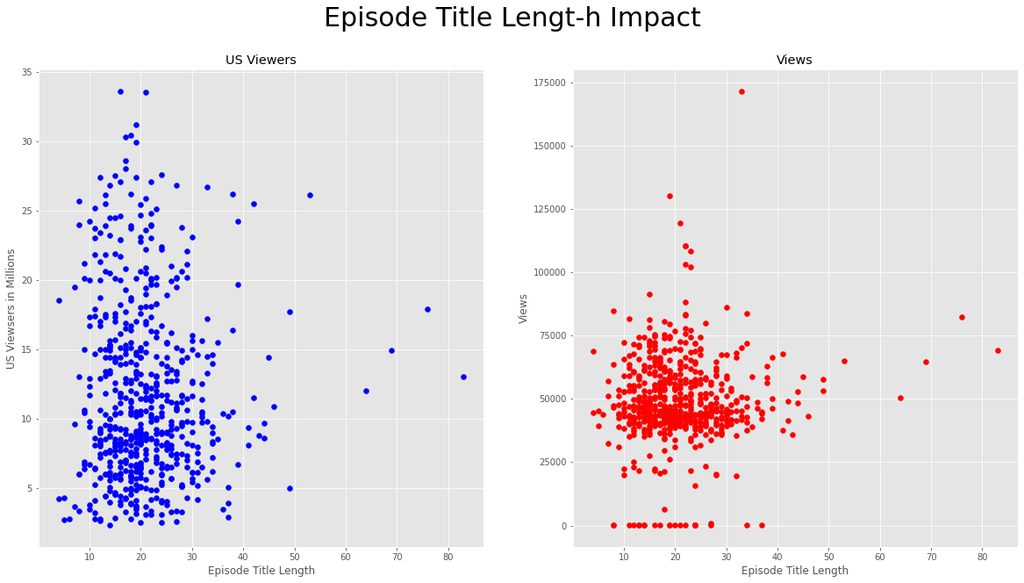

```python
plt.style.use("ggplot")
fig, (ax1, ax2) = plt.subplots(1, 2, sharex = True, figsize = (20, 10))

viewers = ax1.scatter('title_length', 'us_viewers_in_millions', data = main, color = 'blue')
views = ax2.scatter('title_length', 'views', data = main, color = 'red')


plt.suptitle('Episode Title Lengt-h Impact', fontsize = 30)
# title over the whole graph of 2x2 plots

ax1.set(xlabel = 'Episode Title Length', ylabel = 'US Viewsers in Millions', title = 'US Viewers')
ax2.set(xlabel = 'Episode Title Length', ylabel = 'Views', title = 'Views')

plt.show()
```

Looking at the graph above we can see that the number of US viewers does not affect the numbers of viewes, as the numbers of views pretty much stay in a given range of 100,000 or less for the most part. For these reason both coluums could be used equally to analyze the impact on different lengths of Episode Titles.

We can now start to look and see if a ceartain length of an Epsiode title Correlates with viewer count. For the following we will focus more on the `Number of Viewers in the US` than just `Views`.

```python
plt.style.use("ggplot")
xpoints = main['title_length']
ypoints_us = main['us_viewers_in_millions']

plt.title("Episode Title Length vs. Views", size = 20)
plt.xlabel('Length of Episode Titles')
plt.ylabel('Views in Millions')


length_vs_views = plt.scatter(xpoints, ypoints_us, color = 'red');
```

[output not shown]

We can see that our data is very cramped and conjested, so we can set some limits on the axes so that we can better understand the data, without the outliers.

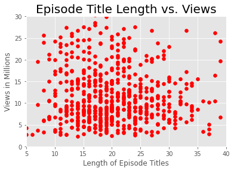

```python
plt.style.use("ggplot")
xpoints = main['title_length']
ypoints_us = main['us_viewers_in_millions']

# Setting axis limits
plt.ylim(0, 30)
plt.xlim(5, 40)
# Seeting axis labels
plt.title("Episode Title Length vs. Views", size = 20)
plt.xlabel('Length of Episode Titles')
plt.ylabel('Views in Millions')

plt.scatter(xpoints, ypoints_us, color = 'red');
```

From the scatter plot above shows that the episodes with the most views when the title is roughly under 30 characters long. After 30 charactersa long, we can see that those episode get a pretty good amount of views but not as many as shorter title episodes.

#### Original Airing Years vs. Viewers

```python
viewers_per_year = main.groupby('original_air_year')[['us_viewers_in_millions', 'episode_age']].mean()
viewers_per_year
```

| original_air_year | us_viewers_in_millions | episode_age |
| --- | --- | --- |
| 1989 | 26.700000 | 33.0 |
| 1990 | 27.504762 | 32.0 |
| 1991 | 22.248000 | 31.0 |
| 1992 | 22.004348 | 30.0 |
| 1993 | 21.304762 | 29.0 |
| 1994 | 17.078261 | 28.0 |
| 1995 | 15.528000 | 27.0 |
| 1996 | 14.015000 | 26.0 |
| 1997 | 13.211538 | 25.0 |
| 1998 | 8.791667 | 24.0 |
| 1999 | 8.835652 | 23.0 |
| 2000 | 11.568095 | 22.0 |
| 2001 | 14.894737 | 21.0 |
| 2002 | 12.859091 | 20.0 |
| 2003 | 13.601739 | 19.0 |
| 2004 | 10.435000 | 18.0 |
| 2005 | 10.396000 | 17.0 |
| 2006 | 9.249545 | 16.0 |
| 2007 | 9.015000 | 15.0 |
| 2008 | 7.740000 | 14.0 |
| 2009 | 6.972857 | 13.0 |
| 2010 | 7.128333 | 12.0 |
| 2011 | 6.717727 | 11.0 |
| 2012 | 5.785238 | 10.0 |
| 2013 | 5.308182 | 9.0 |
| 2014 | 5.099565 | 8.0 |
| 2015 | 4.267727 | 7.0 |
| 2016 | 3.407143 | 6.0 |

I am trying to figure out how to access the different years from the groupby preformed earlier.

```python
viewers_per_year.index
```

```
Int64Index([1989, 1990, 1991, 1992, 1993, 1994, 1995, 1996, 1997, 1998, 1999,
            2000, 2001, 2002, 2003, 2004, 2005, 2006, 2007, 2008, 2009, 2010,
            2011, 2012, 2013, 2014, 2015, 2016],
           dtype='int64', name='original_air_year')
```

```python
years = viewers_per_year.index
years
```

```
Int64Index([1989, 1990, 1991, 1992, 1993, 1994, 1995, 1996, 1997, 1998, 1999,
            2000, 2001, 2002, 2003, 2004, 2005, 2006, 2007, 2008, 2009, 2010,
            2011, 2012, 2013, 2014, 2015, 2016],
           dtype='int64', name='original_air_year')
```

```python
viewers_per_year[:]
```

| original_air_year | us_viewers_in_millions | episode_age |
| --- | --- | --- |
| 1989 | 26.700000 | 33.0 |
| 1990 | 27.504762 | 32.0 |
| 1991 | 22.248000 | 31.0 |
| 1992 | 22.004348 | 30.0 |
| 1993 | 21.304762 | 29.0 |
| 1994 | 17.078261 | 28.0 |
| 1995 | 15.528000 | 27.0 |
| 1996 | 14.015000 | 26.0 |
| 1997 | 13.211538 | 25.0 |
| 1998 | 8.791667 | 24.0 |
| 1999 | 8.835652 | 23.0 |
| 2000 | 11.568095 | 22.0 |
| 2001 | 14.894737 | 21.0 |
| 2002 | 12.859091 | 20.0 |
| 2003 | 13.601739 | 19.0 |
| 2004 | 10.435000 | 18.0 |
| 2005 | 10.396000 | 17.0 |
| 2006 | 9.249545 | 16.0 |
| 2007 | 9.015000 | 15.0 |
| 2008 | 7.740000 | 14.0 |
| 2009 | 6.972857 | 13.0 |
| 2010 | 7.128333 | 12.0 |
| 2011 | 6.717727 | 11.0 |
| 2012 | 5.785238 | 10.0 |
| 2013 | 5.308182 | 9.0 |
| 2014 | 5.099565 | 8.0 |
| 2015 | 4.267727 | 7.0 |
| 2016 | 3.407143 | 6.0 |

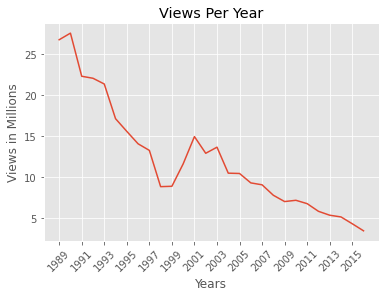

```python
plt.style.use("ggplot")
fig, ax = plt.subplots()
ax.plot(years, viewers_per_year['us_viewers_in_millions'])

ax.set_title("Views Per Year")
ax.set_xlabel("Years")
ax.set_ylabel("Views in Millions")
plt.xticks(rotation = 45) # Rotates the x-axis ticks
plt.xticks(np.arange(1989, 2016, 2)); # Seeting the X-axis labels to the years needed and increments by 2.
```

This graph above shows the mean of US Viewers per year. But this does not tell us a lot of new information because as olders epsidoes have been out longer they. have more time to gain more viewers. So we can do some calculations to normalize the data and get a better sense if older epsiodes are more popular than new ones or the other way around.

We can start by adding a few columns to work on mormalizing the data.

```python
viewers_per_year['normalized_views'] = viewers_per_year['us_viewers_in_millions'] / viewers_per_year['episode_age']
viewers_per_year
```

| original_air_year | us_viewers_in_millions | episode_age | normalized_views |
| --- | --- | --- | --- |
| 1989 | 26.700000 | 33.0 | 0.809091 |
| 1990 | 27.504762 | 32.0 | 0.859524 |
| 1991 | 22.248000 | 31.0 | 0.717677 |
| 1992 | 22.004348 | 30.0 | 0.733478 |
| 1993 | 21.304762 | 29.0 | 0.734647 |
| 1994 | 17.078261 | 28.0 | 0.609938 |
| 1995 | 15.528000 | 27.0 | 0.575111 |
| 1996 | 14.015000 | 26.0 | 0.539038 |
| 1997 | 13.211538 | 25.0 | 0.528462 |
| 1998 | 8.791667 | 24.0 | 0.366319 |
| 1999 | 8.835652 | 23.0 | 0.384159 |
| 2000 | 11.568095 | 22.0 | 0.525823 |
| 2001 | 14.894737 | 21.0 | 0.709273 |
| 2002 | 12.859091 | 20.0 | 0.642955 |
| 2003 | 13.601739 | 19.0 | 0.715881 |
| 2004 | 10.435000 | 18.0 | 0.579722 |
| 2005 | 10.396000 | 17.0 | 0.611529 |
| 2006 | 9.249545 | 16.0 | 0.578097 |
| 2007 | 9.015000 | 15.0 | 0.601000 |
| 2008 | 7.740000 | 14.0 | 0.552857 |
| 2009 | 6.972857 | 13.0 | 0.536374 |
| 2010 | 7.128333 | 12.0 | 0.594028 |
| 2011 | 6.717727 | 11.0 | 0.610702 |
| 2012 | 5.785238 | 10.0 | 0.578524 |
| 2013 | 5.308182 | 9.0 | 0.589798 |
| 2014 | 5.099565 | 8.0 | 0.637446 |
| 2015 | 4.267727 | 7.0 | 0.609675 |
| 2016 | 3.407143 | 6.0 | 0.567857 |

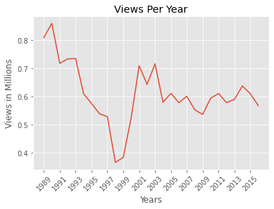

```python
plt.style.use("ggplot")
fig, ax = plt.subplots()
ax.plot(years, viewers_per_year['normalized_views'])

ax.set_title("Views Per Year")
ax.set_xlabel("Years")
ax.set_ylabel("Views in Millions")
plt.xticks(rotation = 45) # Rotates the x-axis ticks
plt.xticks(np.arange(1989, 2016, 2)); # Seeting the X-axis labels to the years needed and increments by 2.
```

Looking at the graph above we can maybe get a better understanding of what years may have produced better seasons of the episodes based on the number of viewers.

Looking at the graphs below, (These have been made previously)

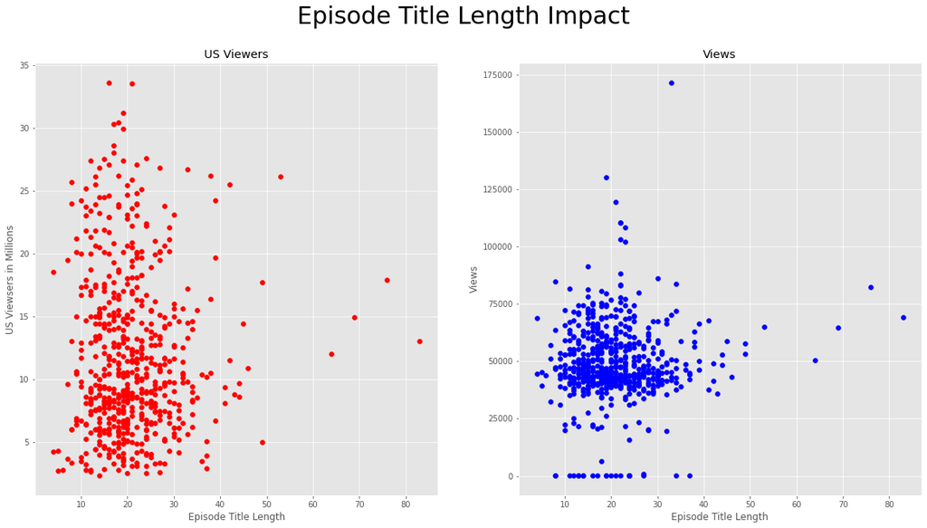

```python
plt.style.use("ggplot")
fig, (ax1, ax2) = plt.subplots(1, 2, sharex = True, figsize = (20, 10))

viewers = ax1.scatter('title_length', 'us_viewers_in_millions', data = main, color = 'red')
views = ax2.scatter('title_length', 'views', data = main, color = 'blue')


plt.suptitle('Episode Title Length Impact', fontsize = 30)
# title over the whole graph of 2x2 plots

ax1.set(xlabel = 'Episode Title Length', ylabel = 'US Viewsers in Millions', title = 'US Viewers')
ax2.set(xlabel = 'Episode Title Length', ylabel = 'Views', title = 'Views')
plt.show()
```

It is really hard to see which data is better to use to make proper judgements. One of the problem with the data for views is that each one has a different amount of time to be able to acvcumulate views. We can fix this For the following studies I am going to base my observations based on the normalized views as it makes the "playing field", for the the data a bit more fair for everything, a new colunm with be created to see the normalized views per episode.

```python
main['normalized_views'] = main['us_viewers_in_millions'] / main['episode_age']
# 'normalized_views' are based on millions
main
```

|  | id | imdb_rating | imdb_votes | number_in_season | number_in_series | original_air_date | original_air_year | season | title | us_viewers_in_millions | views | title_length | episode_age | normalized_views |
| --- | --- | --- | --- | --- | --- | --- | --- | --- | --- | --- | --- | --- | --- | --- |
| 0 | 10 | 7.4 | 1511.0 | 10 | 10 | 1990-03-25 | 1990 | 1 | Homer's Night Out | 30.30 | 50816.0 | 17 | 32 | 0.946875 |
| 1 | 12 | 8.3 | 1716.0 | 12 | 12 | 1990-04-29 | 1990 | 1 | Krusty Gets Busted | 30.40 | 62561.0 | 18 | 32 | 0.950000 |
| 2 | 14 | 8.2 | 1638.0 | 1 | 14 | 1990-10-11 | 1990 | 2 | Bart Gets an "F" | 33.60 | 59575.0 | 16 | 32 | 1.050000 |
| 3 | 17 | 8.1 | 1457.0 | 4 | 17 | 1990-11-01 | 1990 | 2 | Two Cars in Every Garage and Three Eyes on Eve... | 26.10 | 64959.0 | 53 | 32 | 0.815625 |
| 4 | 19 | 8.0 | 1366.0 | 6 | 19 | 1990-11-15 | 1990 | 2 | Dead Putting Society | 25.40 | 50691.0 | 20 | 32 | 0.793750 |
| ... | ... | ... | ... | ... | ... | ... | ... | ... | ... | ... | ... | ... | ... | ... |
| 595 | 500 | 7.0 | 580.0 | 14 | 500 | 2012-02-19 | 2012 | 23 | At Long Last Leave | 5.77 | 45226.0 | 18 | 10 | 0.577000 |
| 596 | 502 | 7.3 | 541.0 | 16 | 502 | 2012-03-11 | 2012 | 23 | How I Wet Your Mother | 4.97 | 44818.0 | 21 | 10 | 0.497000 |
| 597 | 511 | 6.9 | 460.0 | 3 | 511 | 2012-11-04 | 2012 | 24 | Adventures in Baby-Getting | 5.65 | 39687.0 | 26 | 10 | 0.565000 |
| 598 | 542 | 6.4 | 473.0 | 12 | 542 | 2014-03-09 | 2014 | 25 | Diggs | 2.69 | 39292.0 | 5 | 8 | 0.336250 |
| 599 | 548 | 7.0 | 504.0 | 18 | 548 | 2014-04-13 | 2014 | 25 | Days of Future Future | 3.64 | 55742.0 | 21 | 8 | 0.455000 |

600 rows × 14 columns

Now that the `normalized_views` columns ha been made I will start just using this information, for the rest of the time.

#### Season vs. Views

Let's start by getting the avverega number of views per season and then average it based on the number of seasons that is has been released for.

```python
seasons_per_views = main.groupby('season')['normalized_views'].mean()
seasons = seasons_per_views.index
seasons_per_views
```

```
season
1     0.867045
2     0.776118
3     0.713813
4     0.759415
5     0.665237
6     0.568286
7     0.553880
8     0.577797
9     0.409600
10    0.374231
11    0.392087
12    0.724634
13    0.614329
14    0.745921
15    0.598838
16    0.601793
17    0.580737
18    0.593023
19    0.570864
20    0.526099
21    0.576193
22    0.619649
23    0.588099
24    0.575611
25    0.596698
26    0.641331
27    0.619481
28    0.560000
Name: normalized_views, dtype: float64
```

Now that we have done the groupby, lets put it into a graph to get a better visulization to draw our observations easier.

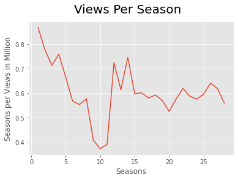

```python
plt.style.use("ggplot")
fig, ax = plt.subplots()
ax.plot(seasons, seasons_per_views)

plt.suptitle('Views Per Season', fontsize = 20)
# title over the whole graph of 2x2 plots

ax.set(xlabel = 'Seasons', ylabel = 'Seasons per Views in Million')

plt.show()
```

We can see from the graph above it look identical to the grape we made earlier because each season time frame is based around the starting of each year, so it would make less sense if the two graphs did not match up.

Lets now look at which parts of the different seasons.

Lets start by see the most of amount of episode an seasn has to figue out a standard range or episodes for each season

```python
numEpisodes = main.groupby('season')['number_in_season'].count()
numEpisodes
```

```
season
1     13
2     22
3     24
4     22
5     22
6     25
7     25
8     25
9     25
10    23
11    22
12    21
13    22
14    22
15    22
16    21
17    22
18    22
19    20
20    21
21    23
22    22
23    22
24    22
25    22
26    22
27    22
28     4
Name: number_in_season, dtype: int64
```

```python
numInSeason_cut = pd.cut(main['number_in_season'], [0,7,15, 25])
numInSeason_cut
```

```
0       (7, 15]
1       (7, 15]
2        (0, 7]
3        (0, 7]
4        (0, 7]
         ...
595     (7, 15]
596    (15, 25]
597      (0, 7]
598     (7, 15]
599    (15, 25]
Name: number_in_season, Length: 600, dtype: category
Categories (3, interval[int64, right]): [(0, 7] < (7, 15] < (15, 25]]
```

We have now grouped each season into roulghly 3 equal parts, we can start to understand which part of each season does the best or does that worst.

Lets see if all season have about the same number of episdoes.

```python
numEpisodes
```

```
season
1     13
2     22
3     24
4     22
5     22
6     25
7     25
8     25
9     25
10    23
11    22
12    21
13    22
14    22
15    22
16    21
17    22
18    22
19    20
20    21
21    23
22    22
23    22
24    22
25    22
26    22
27    22
28     4
Name: number_in_season, dtype: int64
```

We can see that seasons 1 and 28 eiither are shorter seqason or that do not have all of the date for the whole season, so we can drop those 2 seasons as they are an outlier and do not help really.

```python
main_2_27 = main[main['season'] != 1]
main_2_27 = main_2_27[main_2_27['season'] != 28]
main_2_27
```

|  | id | imdb_rating | imdb_votes | number_in_season | number_in_series | original_air_date | original_air_year | season | title | us_viewers_in_millions | views | title_length | episode_age | normalized_views |
| --- | --- | --- | --- | --- | --- | --- | --- | --- | --- | --- | --- | --- | --- | --- |
| 2 | 14 | 8.2 | 1638.0 | 1 | 14 | 1990-10-11 | 1990 | 2 | Bart Gets an "F" | 33.60 | 59575.0 | 16 | 32 | 1.050000 |
| 3 | 17 | 8.1 | 1457.0 | 4 | 17 | 1990-11-01 | 1990 | 2 | Two Cars in Every Garage and Three Eyes on Eve... | 26.10 | 64959.0 | 53 | 32 | 0.815625 |
| 4 | 19 | 8.0 | 1366.0 | 6 | 19 | 1990-11-15 | 1990 | 2 | Dead Putting Society | 25.40 | 50691.0 | 20 | 32 | 0.793750 |
| 5 | 21 | 8.4 | 1522.0 | 8 | 21 | 1990-12-06 | 1990 | 2 | Bart the Daredevil | 26.20 | 57605.0 | 18 | 32 | 0.818750 |
| 6 | 23 | 7.8 | 1340.0 | 10 | 23 | 1991-01-10 | 1991 | 2 | Bart Gets Hit by a Car | 24.80 | 56486.0 | 22 | 31 | 0.800000 |
| ... | ... | ... | ... | ... | ... | ... | ... | ... | ... | ... | ... | ... | ... | ... |
| 595 | 500 | 7.0 | 580.0 | 14 | 500 | 2012-02-19 | 2012 | 23 | At Long Last Leave | 5.77 | 45226.0 | 18 | 10 | 0.577000 |
| 596 | 502 | 7.3 | 541.0 | 16 | 502 | 2012-03-11 | 2012 | 23 | How I Wet Your Mother | 4.97 | 44818.0 | 21 | 10 | 0.497000 |
| 597 | 511 | 6.9 | 460.0 | 3 | 511 | 2012-11-04 | 2012 | 24 | Adventures in Baby-Getting | 5.65 | 39687.0 | 26 | 10 | 0.565000 |
| 598 | 542 | 6.4 | 473.0 | 12 | 542 | 2014-03-09 | 2014 | 25 | Diggs | 2.69 | 39292.0 | 5 | 8 | 0.336250 |
| 599 | 548 | 7.0 | 504.0 | 18 | 548 | 2014-04-13 | 2014 | 25 | Days of Future Future | 3.64 | 55742.0 | 21 | 8 | 0.455000 |

583 rows × 14 columns

```python
ep_cut = pd.cut(main_2_27['number_in_season'], [0,7,15, 25])
ep_cut
```

```
2        (0, 7]
3        (0, 7]
4        (0, 7]
5       (7, 15]
6       (7, 15]
         ...
595     (7, 15]
596    (15, 25]
597      (0, 7]
598     (7, 15]
599    (15, 25]
Name: number_in_season, Length: 583, dtype: category
Categories (3, interval[int64, right]): [(0, 7] < (7, 15] < (15, 25]]
```

```python
ep_piv = main_2_27.pivot_table('normalized_views', ['season', ep_cut])
ep_piv
```

| season | number_in_season | normalized_views |
| --- | --- | --- |
| 2 | (0, 7] | 0.867857 |
|  | (7, 15] | 0.804788 |
|  | (15, 25] | 0.651613 |
| 3 | (0, 7] | 0.679724 |
|  | (7, 15] | 0.758347 |
| ... | ... | ... |
| 26 | (7, 15] | 0.648103 |
|  | (15, 25] | 0.462245 |
| 27 | (0, 7] | 0.656531 |
|  | (7, 15] | 0.742232 |
|  | (15, 25] | 0.442143 |

78 rows × 1 columns

```python
x = main_2_27.groupby([ep_cut, 'season'])['normalized_views'].mean()
first = x[0:26]
second = x[26:52]
third = x[52:]
```

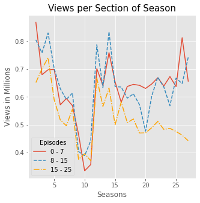

```python
plt.style.use("ggplot")
fig, ax = plt.subplots(figsize = (5, 5))

X = np.arange(2, 28)
ax.plot(X, first, ls = 'solid', linewidth = 1.5)
ax.plot(X, second, ls = 'dashed')
ax.plot(X, third, ls = 'dashdot', color = 'orange')
ax.legend(['0 - 7', '8 - 15', '15 - 25'], title = "Episodes", prop ={'size': 10}) # must include labels for the legend
ax.set_title("Views per Section of Season", size = 15)
ax.set_xlabel('Seasons')
ax.set_ylabel('Views in Millions')

plt.show()
```

By looking at the views based on the episode range it is in, we can that the eariler episodes in each season tend to be more popular that later epidoses. We can also say that roughly the fist 2/3 of every season tend to be more popular than the last the laast third of each season. We can also see that each range of episodes within each season, stay together in terms of views.

Let's look at an overall standing of which part of the seasons seem to be the most popular.

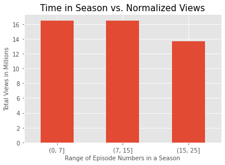

```python
plt.style.use("ggplot")
totalSeasons = ep_piv.groupby('number_in_season')['normalized_views'].sum()

totalSeasons.plot(kind = 'bar')
plt.xticks(rotation = 0)
# Setting Titles
plt.title("Time in Season vs. Normalized Views", size = 15)
plt.ylabel("Total Views in Millions", size = 10)
plt.xlabel("Range of Episode Numbers in a Season", size = 10)
```

We can see on an overall basis, episodes that are earlier in the season and closer to the middle of the season seem to have the most popularity. In simpiler terms, the first 2/3 o of the season seem to draw in the most views.

#### IMDB Ratings and Votes

**What is an IMBD Rating or IMDB Vote?**

IMDb registered users can cast a vote (from 1 to 10) on every released title in a TV series. Individual votes are then aggregated and summarized as a single IMDb rating, visible on the title's main page. For the following study lets first see if there is somewhat of a relation between the IMBD rating is linked to the number of IMBD votes or the other way around.

To make it easier lets loook at the ratings and votes from IMDB for each season compared to the views.

```python
imdb = main_2_27.groupby('season')['imdb_votes','imdb_rating'].mean()
imdb
```

| season | imdb_votes | imdb_rating |
| --- | --- | --- |
| 2 | 1416.454545 | 8.040909 |
| 3 | 1311.916667 | 8.154167 |
| 4 | 1347.500000 | 8.268182 |
| 5 | 1264.545455 | 8.336364 |
| 6 | 1235.240000 | 8.312000 |
| 7 | 1184.560000 | 8.324000 |
| 8 | 1233.560000 | 8.220000 |
| 9 | 1013.360000 | 7.844000 |
| 10 | 880.000000 | 7.569565 |
| 11 | 792.136364 | 7.290909 |
| 12 | 771.619048 | 7.361905 |
| 13 | 673.727273 | 7.140909 |
| 14 | 626.818182 | 7.077273 |
| 15 | 599.409091 | 7.045455 |
| 16 | 576.476190 | 7.042857 |
| 17 | 600.590909 | 6.863636 |
| 18 | 655.727273 | 7.000000 |
| 19 | 678.150000 | 6.935000 |
| 20 | 635.809524 | 6.895238 |
| 21 | 544.434783 | 6.821739 |
| 22 | 513.954545 | 6.804545 |
| 23 | 579.636364 | 6.813636 |
| 24 | 440.363636 | 6.777273 |
| 25 | 486.000000 | 6.831818 |
| 26 | 451.863636 | 6.704545 |
| 27 | 325.136364 | 6.786364 |

I am going to also add a column of the age of each season as it might be useful to have to ubserve certain things.

```python
imdb['age'] = main_2_27.groupby('season')['episode_age'].max()
imdb
```

| season | imdb_votes | imdb_rating | age |
| --- | --- | --- | --- |
| 2 | 1416.454545 | 8.040909 | 32 |
| 3 | 1311.916667 | 8.154167 | 31 |
| 4 | 1347.500000 | 8.268182 | 30 |
| 5 | 1264.545455 | 8.336364 | 29 |
| 6 | 1235.240000 | 8.312000 | 28 |
| 7 | 1184.560000 | 8.324000 | 27 |
| 8 | 1233.560000 | 8.220000 | 26 |
| 9 | 1013.360000 | 7.844000 | 25 |
| 10 | 880.000000 | 7.569565 | 24 |
| 11 | 792.136364 | 7.290909 | 23 |
| 12 | 771.619048 | 7.361905 | 22 |
| 13 | 673.727273 | 7.140909 | 21 |
| 14 | 626.818182 | 7.077273 | 20 |
| 15 | 599.409091 | 7.045455 | 19 |
| 16 | 576.476190 | 7.042857 | 18 |
| 17 | 600.590909 | 6.863636 | 17 |
| 18 | 655.727273 | 7.000000 | 16 |
| 19 | 678.150000 | 6.935000 | 15 |
| 20 | 635.809524 | 6.895238 | 14 |
| 21 | 544.434783 | 6.821739 | 13 |
| 22 | 513.954545 | 6.804545 | 12 |
| 23 | 579.636364 | 6.813636 | 11 |
| 24 | 440.363636 | 6.777273 | 10 |
| 25 | 486.000000 | 6.831818 | 9 |
| 26 | 451.863636 | 6.704545 | 8 |
| 27 | 325.136364 | 6.786364 | 7 |

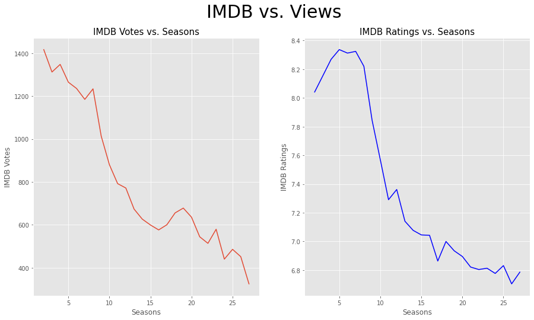

```python
plt.style.use("ggplot")
fig, (ax1, ax2) = plt.subplots(1,2, figsize = (15, 8))

ax1.plot(imdb.index, imdb['imdb_votes'])
ax2.plot(imdb.index, imdb['imdb_rating'], color = 'blue')
# Main title
plt.suptitle('IMDB vs. Views', size = 30)
# Graph Ttiles
ax1.set_title('IMDB Votes vs. Seasons', size = 15)
ax2.set_title('IMDB Ratings vs. Seasons', size = 15)
# X-axis labels
ax1.set_xlabel('Seasons', size = 12)
ax2.set_xlabel('Seasons', size = 12)
# Y-axis labels
ax1.set_ylabel('IMDB Votes', size = 12)
ax2.set_ylabel('IMDB Ratings', size = 12)
```

There is a few different things we can see from these two graphs. First of all, both graphs, although are not exactly the same, we can see that the rough follow the same form of decreasing in either ratings or vote as the season progress. Just like the inital graphs of the different collumns of views and viewers. Another thing the graphs have in common with the two graphs of the veiws and views, is that the ratings or votes are not all fair for all seasons.Older seasons will have more votes or ratings than the newer seasons because they have more times to collect votes or ratings. I am going to get around that by making a collum of normalized ratings. I am not going to worry about the votes because the votes are averaged into the ratings.

```python
main_2_27['norm_imdb_rating'] = (main_2_27['imdb_rating']/main_2_27['episode_age'])
main_2_27
```

|  | id | imdb_rating | imdb_votes | number_in_season | number_in_series | original_air_date | original_air_year | season | title | us_viewers_in_millions | views | title_length | episode_age | normalized_views | norm_imdb_rating |
| --- | --- | --- | --- | --- | --- | --- | --- | --- | --- | --- | --- | --- | --- | --- | --- |
| 2 | 14 | 8.2 | 1638.0 | 1 | 14 | 1990-10-11 | 1990 | 2 | Bart Gets an "F" | 33.60 | 59575.0 | 16 | 32 | 1.050000 | 0.256250 |
| 3 | 17 | 8.1 | 1457.0 | 4 | 17 | 1990-11-01 | 1990 | 2 | Two Cars in Every Garage and Three Eyes on Eve... | 26.10 | 64959.0 | 53 | 32 | 0.815625 | 0.253125 |
| 4 | 19 | 8.0 | 1366.0 | 6 | 19 | 1990-11-15 | 1990 | 2 | Dead Putting Society | 25.40 | 50691.0 | 20 | 32 | 0.793750 | 0.250000 |
| 5 | 21 | 8.4 | 1522.0 | 8 | 21 | 1990-12-06 | 1990 | 2 | Bart the Daredevil | 26.20 | 57605.0 | 18 | 32 | 0.818750 | 0.262500 |
| 6 | 23 | 7.8 | 1340.0 | 10 | 23 | 1991-01-10 | 1991 | 2 | Bart Gets Hit by a Car | 24.80 | 56486.0 | 22 | 31 | 0.800000 | 0.251613 |
| ... | ... | ... | ... | ... | ... | ... | ... | ... | ... | ... | ... | ... | ... | ... | ... |
| 595 | 500 | 7.0 | 580.0 | 14 | 500 | 2012-02-19 | 2012 | 23 | At Long Last Leave | 5.77 | 45226.0 | 18 | 10 | 0.577000 | 0.700000 |
| 596 | 502 | 7.3 | 541.0 | 16 | 502 | 2012-03-11 | 2012 | 23 | How I Wet Your Mother | 4.97 | 44818.0 | 21 | 10 | 0.497000 | 0.730000 |
| 597 | 511 | 6.9 | 460.0 | 3 | 511 | 2012-11-04 | 2012 | 24 | Adventures in Baby-Getting | 5.65 | 39687.0 | 26 | 10 | 0.565000 | 0.690000 |
| 598 | 542 | 6.4 | 473.0 | 12 | 542 | 2014-03-09 | 2014 | 25 | Diggs | 2.69 | 39292.0 | 5 | 8 | 0.336250 | 0.800000 |
| 599 | 548 | 7.0 | 504.0 | 18 | 548 | 2014-04-13 | 2014 | 25 | Days of Future Future | 3.64 | 55742.0 | 21 | 8 | 0.455000 | 0.875000 |

583 rows × 15 columns

Now I am ready to make some graphs and see what they have to offer.

To be able to graph this better letws use a groupby.

```python
imdb_ratings = main_2_27.groupby('season')['norm_imdb_rating'].mean()
```

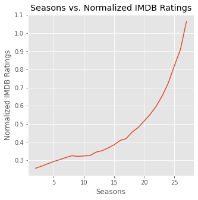

```python
plt.style.use("ggplot")
fig, ax1 = plt.subplots(figsize = (5, 5))


ax1.plot(imdb_ratings.index, imdb_ratings)

# Setting titles
ax1.set_title('Seasons vs. Normalized IMDB Ratings')
ax1.set_xlabel('Seasons')
ax1.set_ylabel('Normalized IMDB Ratings')
```

We can see from the graph above, that the ratings of IMDB grow as new seasons come out.

lets compare this graph to the one comparing the season to views, to see if they give us about the same thing as the graph above.

[figure not shown]

```python
plt.style.use("ggplot")
fig, (ax1, ax2) = plt.subplots(1,2, figsize = (15, 10))

ax1.plot(seasons, seasons_per_views, color = 'blue')
ax2.plot(imdb_ratings.index, imdb_ratings)
# Main title
plt.suptitle('Normalized Views or Normalized Ratings', size = 30)
# Graph Ttiles
ax1.set_title('IMDB Votes vs. Seasons', size = 15)
ax2.set_title('IMDB Ratings vs. Seasons', size = 15)
# X-axis labels
ax1.set_xlabel('Seasons', size = 12)
ax2.set_xlabel('Seasons', size = 12)
# Y-axis labels
ax1.set_ylabel('Normalized Views', size = 12)
ax2.set_ylabel('Normalized IMDB Ratings', size = 12)
plt.show()
```